# A Social Comparison Analysis: Differentiating Losses and Gains? No

# Theoretical and Experimental Recap.

### Prospect Theory’s Domains

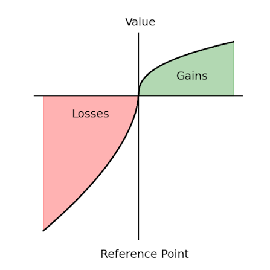

### Experimental Task

[Experimental Task](https://michelegarbelotto.github.io/CV/Experiment.html)

# Hypotheses

### Domain Hypothesis

[figure not shown]

H1: loss domain $\rightarrow$ *less* social comparison

Why?

### Domain Mediated Hypotheses

[figure not shown]

Non-tested HP: loss domain $\rightarrow$ *more* psychological discomfort $\rightarrow$ *less* social comparison

[figure not shown]

H2: loss domain $\rightarrow$ *more* identification $\rightarrow$ *less* social comparison

### Direction Hypothesis

[figure not shown]

H3: *higher* probability of upward comparison $\rightarrow$ *more* social comparison

# Results

## Explanatory Results

### Mixed-Model Hypothesis Tests

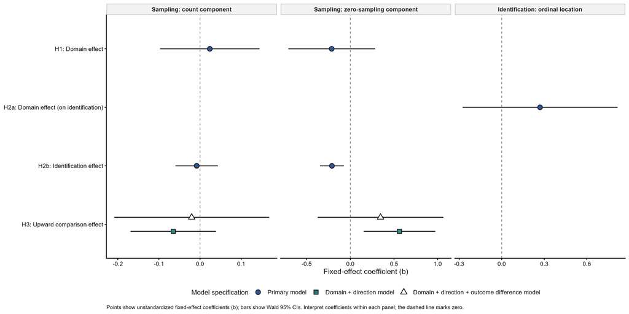

### H3

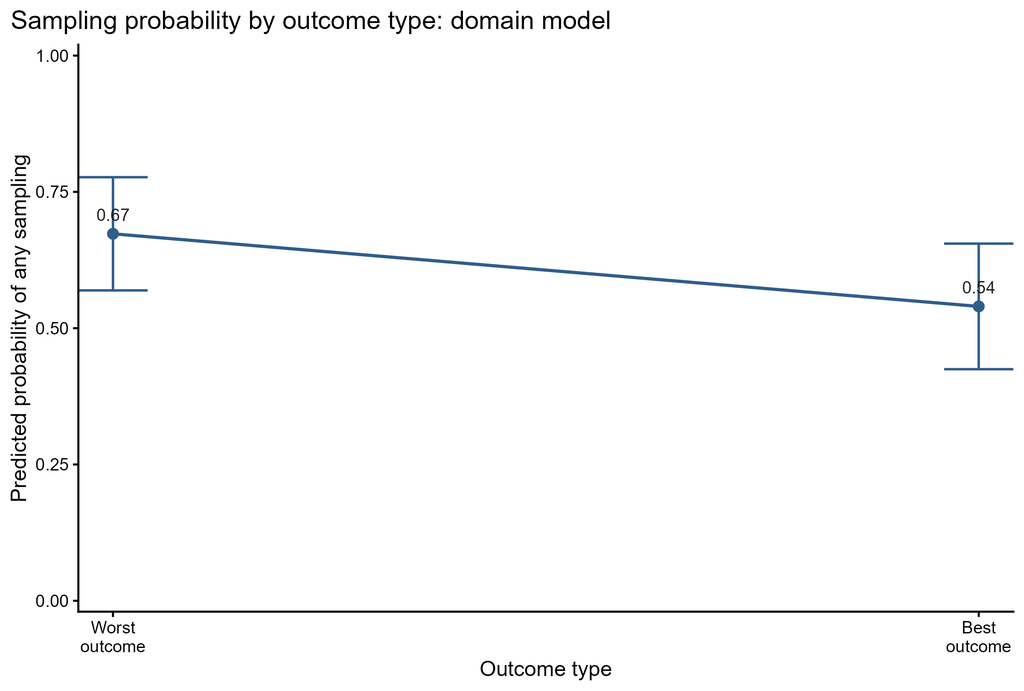

#### Without Outcome Difference

`b = -0.562`, `SE = 0.209`, `p = .007`

#### With Outcome Difference

`b = -0.346`, `SE = 0.367`, `p = .346`

## Exploratory Results

### Model 1

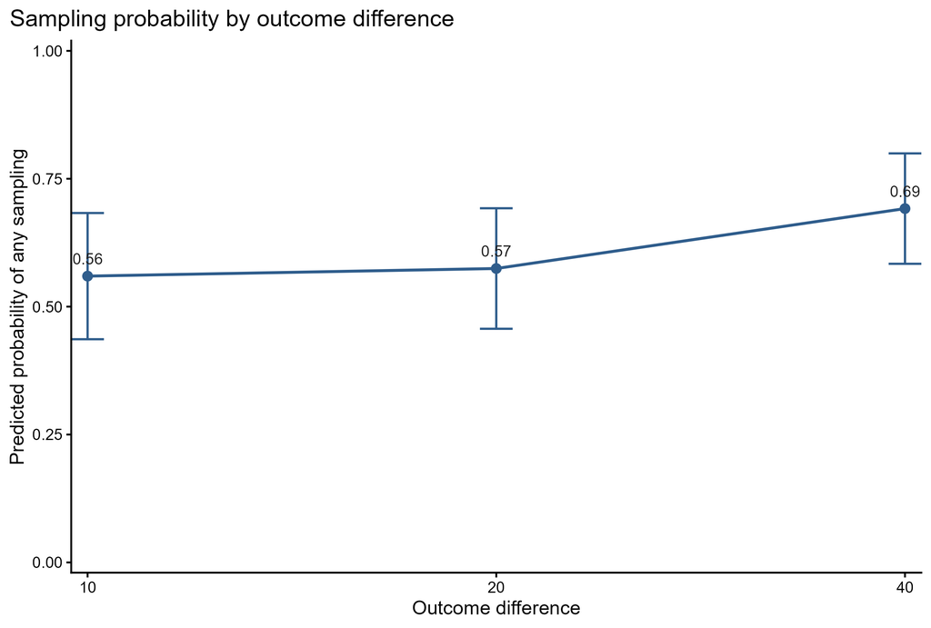

Outcome difference 40-20: `b = 0.513`, `SE = 0.239`, `p = .032` Outcome difference 40-10: `b = 0.585`, `SE = 0.240`, `p = .015`

Model Variables

**Dependent variable**

Sample count

**Displayed outcome**

Probability of any sampling

**Independent variables**

- Outcome difference
- Outcome type
- Domain

### Model 2: Domain

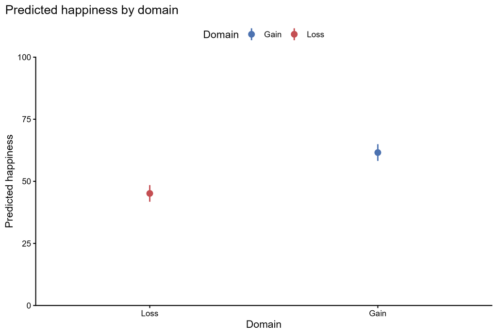

Domain: `b = -16.46`, `SE = 1.88`, `p < .001`

Model Variables

**Dependent variable**

Happiness

**Independent variables**

- Domain
- Block total earnings
- Mean sample count

### Model 2: Block Total Earnings

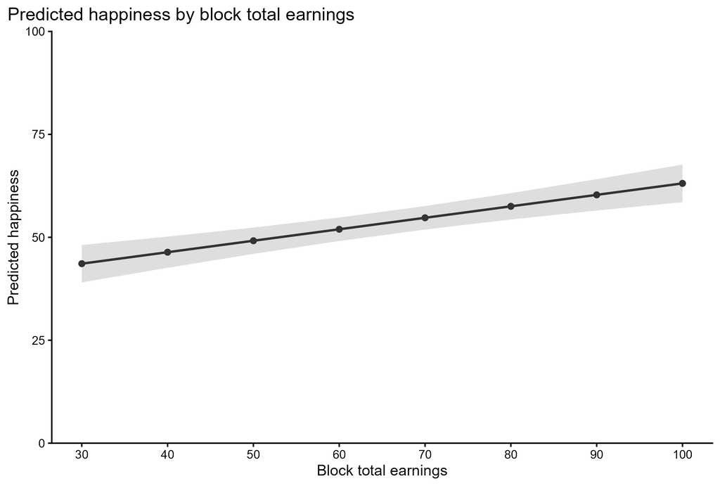

Block total earnings: `b = 0.28`, `SE = 0.05`, `p < .001`

Model Variables

**Dependent variable**

Happiness

**Independent variables**

- Domain
- Block total earnings
- Mean sample count

### Model 2: Mean Sample Count

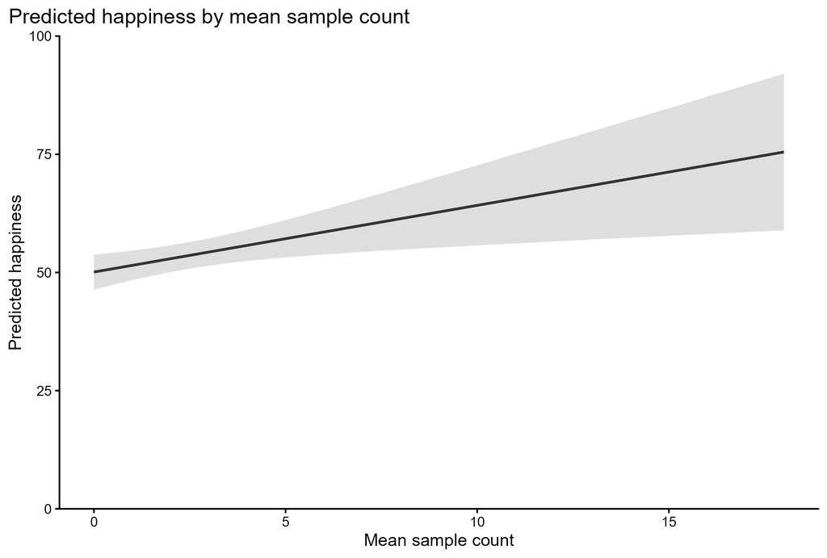

Mean sample count: `b = 1.41`, `SE = 0.53`, `p = .008`

Model Variables

**Dependent variable**

Happiness

**Independent variables**

- Domain
- Block total earnings
- Mean sample count

### Model 3

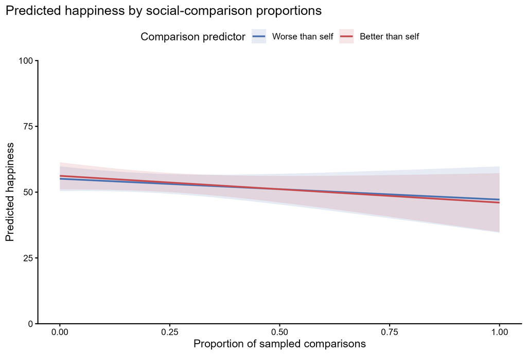

Model Variables

**Dependent variable**

Happiness

**Independent variables**

- Domain
- Block total earnings
- Proportion of comparisons worse than self
- Proportion of comparisons better than self